# Solar Still Performance

Luo Zhouyang

2020/10/19

### Solar Still Types

Different types of solar stills were designed and constructed by the research group, and most of the data was collected on the roof of Zheneng Chuangye Building, Hangzhou. The shape, insulation, absorption and evaporation structure of stills were improved:

- **Trapezoid Solar Still**
  - **Bottom Heating (BH):** Traditional solar still as control group
  - **Sidewall Bottom Heating (SBH):** Traditional solar still as control group for sidewall factor investigation
  - **Bottom Interfacial (BI):** Interfacial evaporation structure only on bottom
  - **Sidewall Bottom Interfacial (SI):** Interfacial evaporation structure on both bottom & sidewall
  - **Foam Bottom Interfacial (FBI):** Foam inside structure with interfacial evaporation on bottom
  - **Foam Sidewall Bottom Interfacial (FSI):** Foam inside structure with interfacial evaporation on both bottom & sidewall
- **Stepwised Solar Still**
- **Pyramid Solar Still**
- **Tube Solar Still**
- **Portable Solar Still**

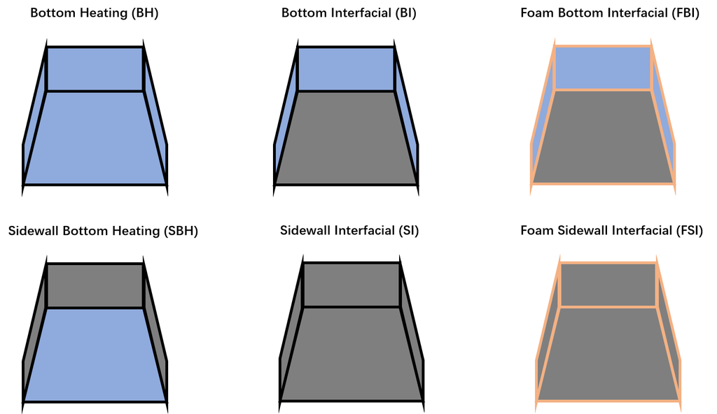

**Figure. Illustration for different solar still types**